# Moral ID and COVID

Results

Cillian McHugh

13th July 2021

# Introduction

[Introduction is here](https://docs.google.com/document/d/1mDV7E6DE7lUiBEDMDcoaAhFGffB4TgVT1DAzisn6kWE/edit?usp=sharing)

# Method

## Participants

A total of sample of *N* = 46744 participants (22377, female, 24169 male, 139 other, *M*<sub>age</sub> = 43.07, min = 18, max = 100, *SD* = 16.01), were recruited from 67 countries.

Isolating just the participants in USA and NZL samples, left a total of *N* = 1980 participants (965, female, 1008 male, 5 other, *M*<sub>age</sub> = 44.7, min = 18, max = 100, *SD* = 16.76). The USA sample consisted of *n* = 1471 participants (710, female, 755 male, 4 other, *M*<sub>age</sub> = 44.32, *SD* = 16.43; and the New Zealand sample consisted of *n* = 509 participants (255, female, 253 male, 1 other, *M*<sub>age</sub> = 45.78, *SD* = 17.63.

## Scale Reliabilities

### Physical Distancing Scale

```
## [1] "Global Sample"
```

```
##
## Cronbach's alpha for the 'y[complete.cases(y), ]' data-set
##
## Items: 5
## Sample units: 46441
## alpha: 0.727
```

```
## [1] "USA & NZL"
```

```
##
## Cronbach's alpha for the 'y[complete.cases(y), ]' data-set
##
## Items: 5
## Sample units: 1974
## alpha: 0.769
```

```
## [1] "USA"
```

```
##
## Cronbach's alpha for the 'y[complete.cases(y), ]' data-set
##
## Items: 5
## Sample units: 1466
## alpha: 0.757
```

```
## [1] "New Zealand"
```

```
##
## Cronbach's alpha for the 'y[complete.cases(y), ]' data-set
##
## Items: 5
## Sample units: 508
## alpha: 0.768
```

### Physical Hygiene Scale

```
## [1] "Global Sample"
```

```
##
## Cronbach's alpha for the 'y[complete.cases(y), ]' data-set
##
## Items: 5
## Sample units: 46248
## alpha: 0.795
```

```
## [1] "USA & NZL"
```

```
##
## Cronbach's alpha for the 'y[complete.cases(y), ]' data-set
##
## Items: 5
## Sample units: 1953
## alpha: 0.851
```

```
## [1] "USA"
```

```
##
## Cronbach's alpha for the 'y[complete.cases(y), ]' data-set
##
## Items: 5
## Sample units: 1446
## alpha: 0.869
```

```
## [1] "New Zealand"
```

```
##
## Cronbach's alpha for the 'y[complete.cases(y), ]' data-set
##
## Items: 5
## Sample units: 507
## alpha: 0.803
```

### Policy Support

```
## [1] "Global Sample"
```

```
##
## Cronbach's alpha for the 'y[complete.cases(y), ]' data-set
##
## Items: 5
## Sample units: 46401
## alpha: 0.87
```

```
## [1] "USA & NZL"
```

```
##
## Cronbach's alpha for the 'y[complete.cases(y), ]' data-set
##
## Items: 5
## Sample units: 1969
## alpha: 0.907
```

```
## [1] "USA"
```

```
##
## Cronbach's alpha for the 'y[complete.cases(y), ]' data-set
##
## Items: 5
## Sample units: 1463
## alpha: 0.91
```

```
## [1] "New Zealand"
```

```
##
## Cronbach's alpha for the 'y[complete.cases(y), ]' data-set
##
## Items: 5
## Sample units: 506
## alpha: 0.875
```

### Internalised Moral Identity

```
## [1] "Global Sample"
```

```
##
## Cronbach's alpha for the 'y[complete.cases(y), ]' data-set
##
## Items: 5
## Sample units: 46123
## alpha: 0.752
```

```
## [1] "USA & NZL"
```

```
##
## Cronbach's alpha for the 'y[complete.cases(y), ]' data-set
##
## Items: 5
## Sample units: 1972
## alpha: 0.733
```

```
## [1] "USA"
```

```
##
## Cronbach's alpha for the 'y[complete.cases(y), ]' data-set
##
## Items: 5
## Sample units: 1464
## alpha: 0.728
```

```
## [1] "New Zealand"
```

```
##
## Cronbach's alpha for the 'y[complete.cases(y), ]' data-set
##
## Items: 5
## Sample units: 508
## alpha: 0.765
```

### Symbolic Moral Identity

```
## [1] "Global Sample"
```

```
##
## Cronbach's alpha for the 'y[complete.cases(y), ]' data-set
##
## Items: 5
## Sample units: 45804
## alpha: 0.818
```

```
## [1] "USA & NZL"
```

```
##
## Cronbach's alpha for the 'y[complete.cases(y), ]' data-set
##
## Items: 5
## Sample units: 1968
## alpha: 0.835
```

```
## [1] "USA"
```

```
##
## Cronbach's alpha for the 'y[complete.cases(y), ]' data-set
##
## Items: 5
## Sample units: 1465
## alpha: 0.84
```

```
## [1] "New Zealand"
```

```
##
## Cronbach's alpha for the 'y[complete.cases(y), ]' data-set
##
## Items: 5
## Sample units: 503
## alpha: 0.802
```

### Risk Perception

```
## [1] "Global Sample"
```

```
##
## Cronbach's alpha for the 'y[complete.cases(y), ]' data-set
##
## Items: 2
## Sample units: 46414
## alpha: 0.804
```

```
## [1] "USA & NZL"
```

```
##
## Cronbach's alpha for the 'y[complete.cases(y), ]' data-set
##
## Items: 2
## Sample units: 1975
## alpha: 0.84
```

```
## [1] "USA"
```

```
##
## Cronbach's alpha for the 'y[complete.cases(y), ]' data-set
##
## Items: 2
## Sample units: 1467
## alpha: 0.818
```

```
## [1] "New Zealand"
```

```
##
## Cronbach's alpha for the 'y[complete.cases(y), ]' data-set
##
## Items: 2
## Sample units: 508
## alpha: 0.869
```

### Narcissism Admiration

```
## [1] "Global Sample"
```

```
##
## Cronbach's alpha for the 'y[complete.cases(y), ]' data-set
##
## Items: 3
## Sample units: 46141
## alpha: 0.795
```

```
## [1] "USA & NZL"
```

```
##
## Cronbach's alpha for the 'y[complete.cases(y), ]' data-set
##
## Items: 3
## Sample units: 1972
## alpha: 0.828
```

```
## [1] "USA"
```

```
##
## Cronbach's alpha for the 'y[complete.cases(y), ]' data-set
##
## Items: 3
## Sample units: 1467
## alpha: 0.832
```

```
## [1] "New Zealand"
```

```
##
## Cronbach's alpha for the 'y[complete.cases(y), ]' data-set
##
## Items: 3
## Sample units: 505
## alpha: 0.794
```

### Narcissism Rivaly

```
## [1] "Global Sample"
```

```
##
## Cronbach's alpha for the 'y[complete.cases(y), ]' data-set
##
## Items: 3
## Sample units: 46250
## alpha: 0.678
```

```
## [1] "USA & NZL"
```

```
##
## Cronbach's alpha for the 'y[complete.cases(y), ]' data-set
##
## Items: 3
## Sample units: 1973
## alpha: 0.812
```

```
## [1] "USA"
```

```
##
## Cronbach's alpha for the 'y[complete.cases(y), ]' data-set
##
## Items: 3
## Sample units: 1467
## alpha: 0.829
```

```
## [1] "New Zealand"
```

```
##
## Cronbach's alpha for the 'y[complete.cases(y), ]' data-set
##
## Items: 3
## Sample units: 506
## alpha: 0.729
```

### Collective Narcissism

```
## [1] "Global Sample"
```

```
##
## Cronbach's alpha for the 'y[complete.cases(y), ]' data-set
##
## Items: 3
## Sample units: 46002
## alpha: 0.869
```

```
## [1] "USA & NZL"
```

```
##
## Cronbach's alpha for the 'y[complete.cases(y), ]' data-set
##
## Items: 3
## Sample units: 1969
## alpha: 0.849
```

```
## [1] "USA"
```

```
##
## Cronbach's alpha for the 'y[complete.cases(y), ]' data-set
##
## Items: 3
## Sample units: 1468
## alpha: 0.861
```

```
## [1] "New Zealand"
```

```
##
## Cronbach's alpha for the 'y[complete.cases(y), ]' data-set
##
## Items: 3
## Sample units: 501
## alpha: 0.803
```

### Conspiracy Beliefs

```
## [1] "Global Sample"
```

```
##
## Cronbach's alpha for the 'y[complete.cases(y), ]' data-set
##
## Items: 4
## Sample units: 46289
## alpha: 0.918
```

```
## [1] "USA & NZL"
```

```
##
## Cronbach's alpha for the 'y[complete.cases(y), ]' data-set
##
## Items: 4
## Sample units: 1971
## alpha: 0.922
```

```
## [1] "USA"
```

```
##
## Cronbach's alpha for the 'y[complete.cases(y), ]' data-set
##
## Items: 4
## Sample units: 1466
## alpha: 0.92
```

```
## [1] "New Zealand"
```

```
##
## Cronbach's alpha for the 'y[complete.cases(y), ]' data-set
##
## Items: 4
## Sample units: 505
## alpha: 0.919
```

# Results

Initial testing revealed that for Policy Support, allowing intercepts to vary with Country significantly improved the predictive power of the model $\chi$<sup>2</sup>(1) = 8290.99, *p* < .001.

Similarly, for Physical Contact, allowing intercepts to vary with Country significantly improved the predictive power of the model $\chi$<sup>2</sup>(1) = 3951.04, *p* < .001.

Finally, for Physical Hygiene, allowing intercepts to vary with Country significantly improved the predictive power of the model $\chi$<sup>2</sup>(1) = 4677.74, *p* < .001. The country level residuals for the full models for each dependent variable are plotted in the Supplementary Analysis.

## Testing Differences Between USA and NZL

In the analysis that follows we focus only on the USA and New Zealand samples (*N* = 1980). We have only reported effects for the variables of interest (Moral Circle, Moral Identity Internalization, Symbolic Moral Identity, Political Ideology, and Country), however the values reported are taken from the full model including relevant covariates, all the full regression tables are reported in the supplementary analysis.

## Basic Associations

Table 1:

*Basic Corrleations total sample*

|  | 1 | 2 | 3 | 4 | 5 | 6 | *M* | SD |
| --- | --- | --- | --- | --- | --- | --- | --- | --- |
| Policy Support | - |  |  |  |  |  | 7.87 | 2.27 |
| Physical Contact | .47*** | - |  |  |  |  | 8.34 | 1.70 |
| Physical Hygiene | .43*** | .42*** | - |  |  |  | 7.93 | 1.89 |
| Moral Circle | .09*** | .12*** | .10*** | - |  |  | 9.36 | 5.25 |
| Moral Identity Internal | .23*** | .30*** | .25*** | .22*** | - |  | 7.77 | 1.73 |
| Moral Identity Symbolic | .14*** | .06*** | .23*** | .08*** | .22*** | - | 5.32 | 2.15 |
| Political Ideology | -.03*** | -.07*** | .01** | -.13*** | -.12*** | .10*** | 4.97 | 2.33 |

Table 2:

*Basic Correlations (USA sample)*

|  | 1 | 2 | 3 | 4 | 5 | 6 | M | SD |
| --- | --- | --- | --- | --- | --- | --- | --- | --- |
| Policy Support | - |  |  |  |  |  | 7.58 | 2.39 |
| Physical Contact | .54*** | - |  |  |  |  | 7.89 | 1.81 |
| Physical Hygiene | .48*** | .50*** | - |  |  |  | 7.99 | 1.90 |
| Moral Circle | .17*** | .19*** | .10*** | - |  |  | 8.94 | 5.19 |
| Moral Identity Internal | .28*** | .55*** | .31*** | .21*** | - |  | 7.37 | 1.91 |
| Moral Identity Symbolic | .23*** | .03 | .33*** | .04 | -.02 | - | 6.07 | 2.13 |
| Political Ideology | -.07** | -.12*** | .14*** | -.10*** | -.14*** | .33*** | 6.11 | 2.69 |

Table 3:

*Basic Correlations (New Zealand sample)*

|  | 1 | 2 | 3 | 4 | 5 | 6 | M | SD |
| --- | --- | --- | --- | --- | --- | --- | --- | --- |
| Policy Support | - |  |  |  |  |  | 8.53 | 1.84 |
| Physical Contact | .50*** | - |  |  |  |  | 8.84 | 1.45 |
| Physical Hygiene | .28*** | .20*** | - |  |  |  | 7.50 | 1.85 |
| Moral Circle | .11* | .08 | .09 | - |  |  | 8.85 | 5.27 |
| Moral Identity Internal | .33*** | .45*** | .18*** | .24*** | - |  | 7.64 | 1.70 |
| Moral Identity Symbolic | .05 | -.10* | .30*** | .05 | .04 | - | 5.37 | 1.91 |
| Political Ideology | -.10* | -.11* | -.01 | -.11* | -.22*** | .14** | 5.23 | 2.12 |

Table 4:

*Means Standard Deviations and Differences between the Samples*

|  | *M*-USA | *SD*-USA | *M*-NZL | *SD*-NZL | *t* | df | *p* | *d* |
| --- | --- | --- | --- | --- | --- | --- | --- | --- |
| Policy Support | 7.58 | 2.39 | 8.53 | 1.84 | 9.22 | 1138.13 | < .001** | 0.42 |
| Physical Contact | 7.89 | 1.81 | 8.84 | 1.45 | 11.85 | 1092.8 | < .001** | 0.55 |
| Physical Hygiene | 7.99 | 1.9 | 7.5 | 1.85 | -5.11 | 903.28 | < .001** | 0.26 |
| Moral Circle | 8.94 | 5.19 | 8.85 | 5.27 | -0.35 | 871.89 | .727 | 0.02 |
| Moral ID Internalization | 7.37 | 1.91 | 7.64 | 1.7 | 3.02 | 982.03 | .003* | 0.15 |
| Symbolic Moral ID | 6.07 | 2.13 | 5.37 | 1.91 | -6.84 | 980.43 | < .001** | 0.33 |
| Political Ideology | 6.11 | 2.69 | 5.23 | 2.12 | -7.53 | 1105.91 | < .001** | 0.35 |

# Policy Support

#### Without Country

First we conducted regression for all variables across the full dataset (without accounting for Country). This model was significant *R*<sup>2</sup> = 0.25, *F*(17, 1932) = 37.28, *p* < .001. Of the variables of interest, Moral Circle *b* = 0.04, 95% CI = [0.00, 0.09], *t*(1932) = 2.00, *p* = .045, Internalized Moral Identity , *b* = 0.24, 95% CI = [0.19, 0.29], *t*(1932) = 9.54, *p* = < .001, and Political Ideology , *b* = -0.16, 95% CI = [-0.20, -0.11], *t*(1932) = -7.11, *p* = < .001, were significant predictors in the model. Furthermore, there was a significant interaction between Political Ideology and both Internalized Moral Identity, *b* = -0.10, 95% CI = [-0.14, -0.07], *t*(1932) = -5.80, *p* < .001, and Symbolic Moral Identity, *b* = 0.09, 95% CI = [0.06, 0.13], *t*(1932) = 5.33, *p* < .001.

#### With Country

Next we added Country as an interaction term. Again the model was significant *R*<sup>2</sup> = 0.3, *F*(35, 1914) = 23.67, *p* < .001. And the model performed significantly better than the previous model *F*(18, 1914) = 8.38, *p* < .001.

Most importantly, we found a significant three way Country × Internalized Moral Identity × Political Ideology interaction, *b* = -0.13, 95% CI = [-0.22, -0.03], *t*(1914) = -2.69, *p* = .007.

#### USA Regression

To interpret these interactions we conducted regressions for the USA and New Zealand samples separately. For the USA sample, the overall model significantly predicted Policy Support *R*<sup>2</sup> = 0.29, *F*(17, 1430) = 34.81, *p* < .001, with both Internalised Moral Identity, *b* = 0.25, 95% CI = [0.19, 0.31], *t*(1430) = 8.28, *p* = < .001, and Political Ideology, *b* = -0.17, 95% CI = [-0.22, -0.12], *t*(1430) = -6.56, *p* = < .001, significantly predicting Policy Support in the USA sample. Importantly the predicted Internalized Moral Identity × Political Ideology interaction was observed *b* = -0.11, 95% CI = [-0.14, -0.07], *t*(1430) = -5.46, *p* = < .001.

We note that in the USA Sample Moral Circle was also a significant predictor *b* = 0.06, 95% CI = [0.01, 0.11], *t*(1430) = 2.35, *p* .019; furthermore we also observed a significant Symbolic Moral Identity × Political Ideology interaction, *b* = 0.10, 95% CI = [0.07, 0.14], *t*(1430) = 5.47, *p* < .001.

#### New Zealand Regression

We note that also that Moral Circle was not a significant predictor *b* = 0.00, 95% CI = [-0.07, 0.07], *t*(484) = 0.01, *p* .991; and we observed no significant Symbolic Moral Identity × Political Ideology interaction, *b* = 0.04, 95% CI = [-0.03, 0.12], *t*(484) = 1.19, *p* .233.

#### Plot

Figure 1 shows the relationship between Political Ideology and Internal Moral Identity in predicting Policy Support for the New Zealand sample and the USA sample separately.

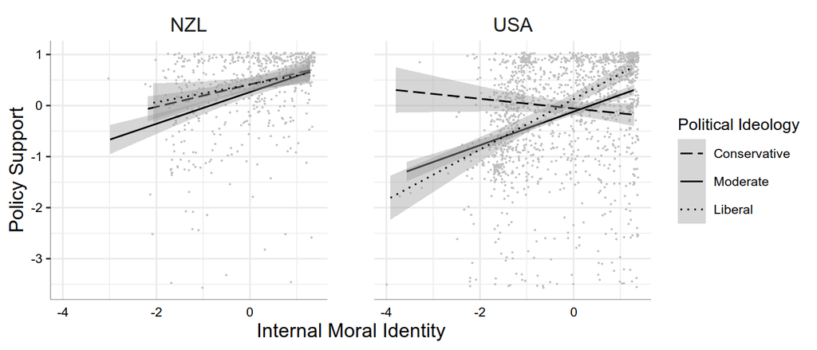

Figure 1: USA: Interaction between Political Ideology and Internal Moral Identity in predicting Policy Support

# Physical Contact

#### With Country

Internalized Moral Identiy remained a significant predictor in the model *b* = 0.36, 95% CI = [0.31, 0.42], *t*(1932) = 13.09, *p* = < .001; and Political Ideology emerged as a significant predictor, *b* = -0.05, 95% CI = [-0.09, 0.00], *t*(1932) = -2.03, *p* = .043. We found a significant interaction between Political Ideology and both Internalized Moral Identity, *b* = -0.05, 95% CI = [-0.08, -0.01], *t*(1932) = -2.67, *p* .008, and Symbolic Moral Identity, *b* = 0.07, 95% CI = [0.04, 0.10], *t*(1932) = 3.98, *p* < .001.

We also observed a significant three way Country × Internalized Moral Identiy × Political Ideology interaction *b* = 0.09, 95% CI = [0.00, 0.18], *t*(1932) = 2.06, *p* .039.

#### USA Regression

Again we conducted regressions for the USA and New Zealand samples separately. For the USA sample, the overall model significantly predicted adherence to Physical Contact measures *R*<sup>2</sup> = 0.4, *F*(17, 1430) = 55.3, *p* < .001, with both Internalised Moral Identity, *b* = 0.36, 95% CI = [0.31, 0.42], *t*(1430) = 12.66, *p* = < .001, and Political Ideology, *b* = -0.05, 95% CI = [-0.10, 0.00], *t*(1430) = -1.96, *p* = .050, significantly predicting adherence to Physical Contact measures in the USA sample. Importantly the predicted Internalized Moral Identity × Political Ideology interaction was observed *b* = -0.05, 95% CI = [-0.08, -0.01], *t*(1430) = -2.59, *p* = .010.

We note that in the USA we also observed a significant Symbolic Moral Identity × Political Ideology interaction *b* = 0.07, 95% CI = [0.03, 0.10], *t*(1430) = 3.85, *p* < .001; and a significant Moral Circle × Symbolic Moral Identity interaction, *b* = 0.04, 95% CI = [0.00, 0.09], *t*(1430) = 2.03, *p* .043.

#### New Zealand Regression

We note that also that a significant Symbolic Moral Identity × Political Ideology interaction was not observed *b* = 0.01, 95% CI = [-0.06, 0.08], *t*(484) = 0.35, *p* .726; nor did we find a a significant significant Moral Circle × Symbolic Moral Identity interaction, *b* = 0.01, 95% CI = [-0.06, 0.08], *t*(484) = 0.21, *p* .831.

#### Plot

Figure 2 shows the relationship between Political Ideology and Internal Moral Identity in predicting Physical Contact for the New Zealand sample and the USA sample separately.

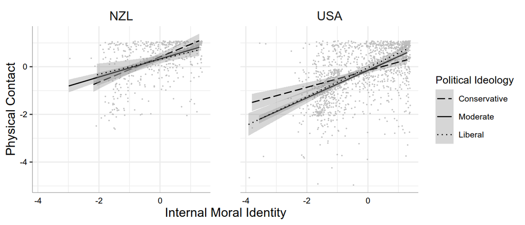

Figure 2: USA: Interaction between Political Ideology and Internal Moral Identity in predicting Physical Contact

# Physical Hygiene

#### Without Country

In line with the previous analyses, we conducted regression for all variables across the full dataset (without accounting for Country), and this model was significant *R*<sup>2</sup> = 0.27, *F*(17, 1931) = 41.61, *p* < .001. Internalized Moral Identity was a significant predictor in the model *b* = 0.21, 95% CI = [0.16, 0.26], *t*(1931) = 8.45, *p* = < .001; as was Symbolic Moral Identity, *b* = 0.23, 95% CI = [0.18, 0.28], *t*(1931) = 8.80, *p* = < .001. We also found a significant interaction between Political Ideology and Internalized Moral Identity, *b* = -0.05, 95% CI = [-0.09, -0.02], *t*(1931) = -3.17, *p* .002.

#### USA Regression

For consistency, we conducted regressions for the USA and New Zealand samples separately. For the USA sample, the overall model significantly predicted adherence to Physical Hygiene measures *R*<sup>2</sup> = 0.31, *F*(17, 1429) = 37.46, *p* < .001

Both Internalized Moral Identity was a significant predictor in the model *b* = 0.23, 95% CI = [0.17, 0.29], *t*(1429) = 8.01, *p* = < .001; as was Symbolic Moral Identity, *b* = 0.21, 95% CI = [0.16, 0.27], *t*(1429) = 7.29, *p* = < .001, were significant predictors in the model, and the significant interaction between Political Ideology and Internalized Moral Identity, *b* = -0.05, 95% CI = [-0.09, -0.02], *t*(1429) = -2.95, *p* .003 was also present.

#### New Zealand Regression

For the New Zealand sample, the overall model was also significant *R*<sup>2</sup> = 0.17, *F*(17, 484) = 5.93, *p* < .001

#### Plot

Figure 3 shows the relationship between Political Ideology and Internal Moral Identity in predicting Physical Hygiene for the New Zealand sample and the USA sample separately (note that these effects are equivalent).

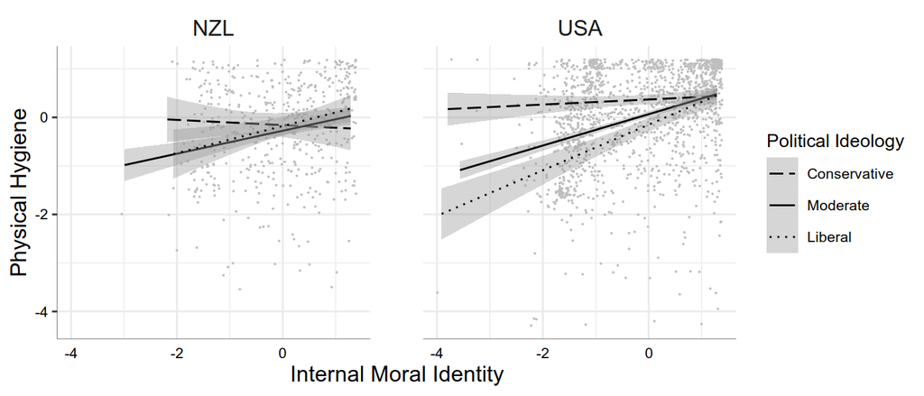

Figure 3: USA: Interaction between Political Ideology and Internal Moral Identity in predicting Physical Hygiene

# Supplementary Analysis

## Residual Plots

### Policy Support Residuals

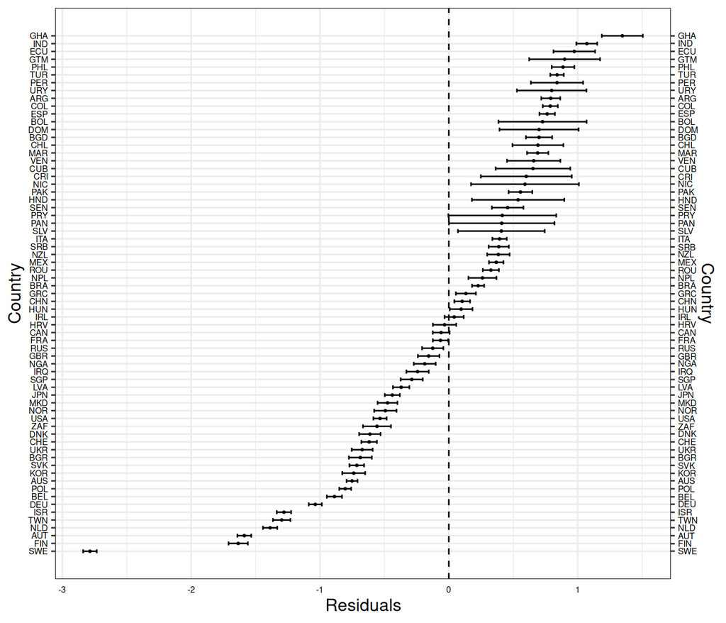

Figure 4: Residuals by Country, predicting Policy Support

### Physical Contact Residuals

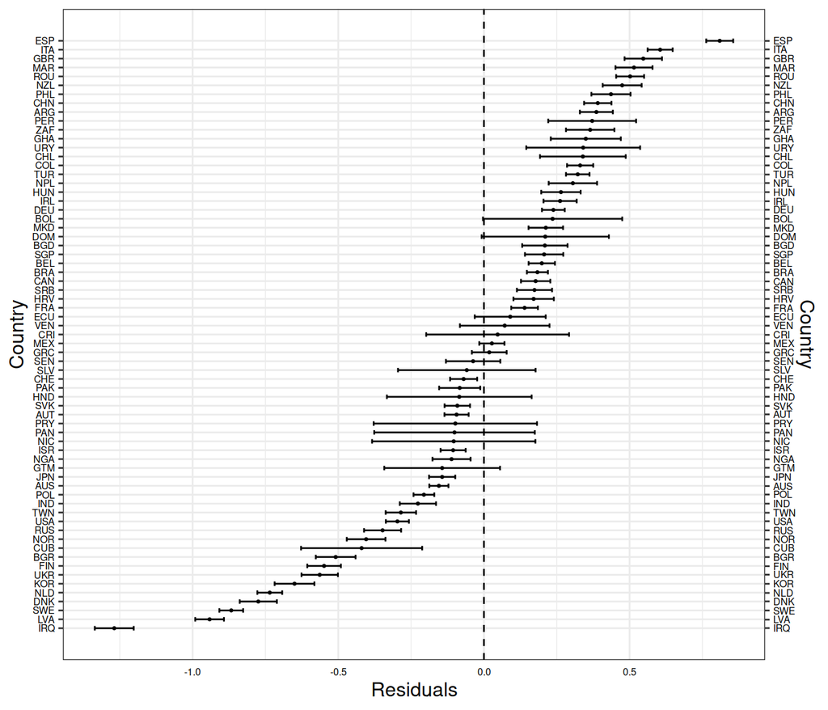

Figure 5: Residuals by Country, predicting adherence to Physical Contact Measures

### Physical Hygiene Residuals

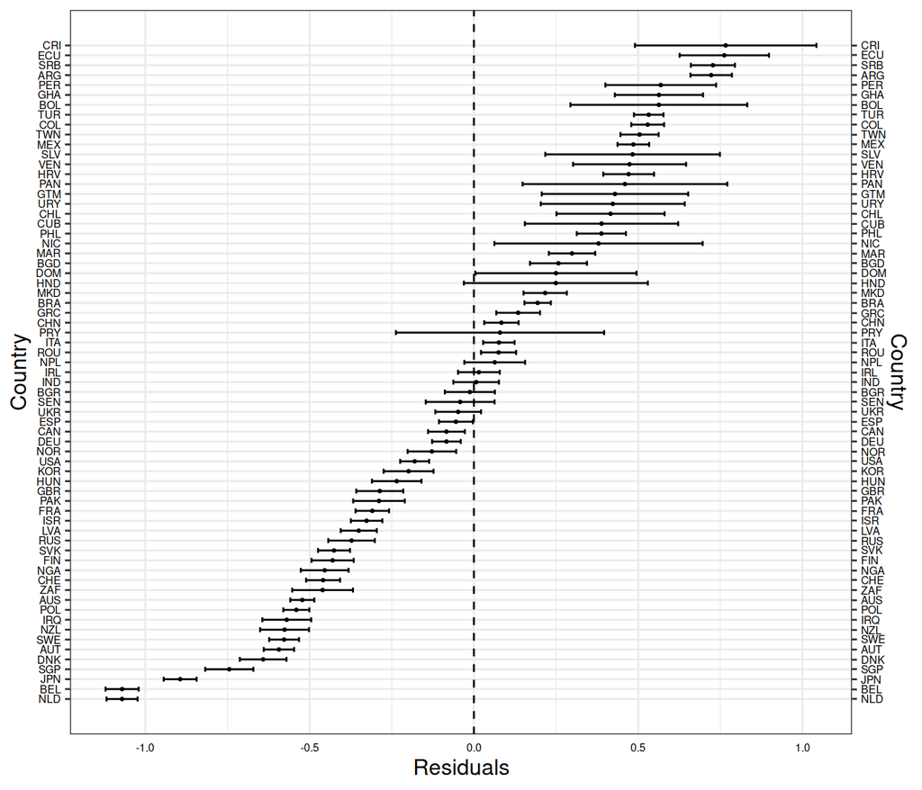

Figure 6: Residuals by Country, predicting adherence to Physical Hygiene Measures

## Basic Associations

Table 5:

*Basic Corrleations total sample*

|  | 1 | 2 | 3 | 4 | 5 | 6 | 7 | 8 | 9 | 10 | 11 | 12 | 13 | *M* | *SD* |
| --- | --- | --- | --- | --- | --- | --- | --- | --- | --- | --- | --- | --- | --- | --- | --- |
| Policy Support | - |  |  |  |  |  |  |  |  |  |  |  |  | 7.87 | 2.27 |
| Physical Contact | .47*** | - |  |  |  |  |  |  |  |  |  |  |  | 8.34 | 1.70 |
| Physical Hygiene | .43*** | .42*** | - |  |  |  |  |  |  |  |  |  |  | 7.93 | 1.89 |
| Age | -.05*** | .09*** | .00 | - |  |  |  |  |  |  |  |  |  | 43.07 | 16.01 |
| Risk Perception | .08*** | .02*** | .07*** | -.11*** | - |  |  |  |  |  |  |  |  | 43.68 | 25.91 |
| Narcissism Admiration | .07*** | -.03*** | .12*** | -.14*** | -.01** | - |  |  |  |  |  |  |  | 4.91 | 2.39 |
| Narcissism Rivalry | -.09*** | -.18*** | -.10*** | -.09*** | .07*** | .46*** | - |  |  |  |  |  |  | 3.48 | 2.28 |
| Collective Narcissism | .14*** | -.01* | .16*** | -.01 | -.03*** | .34*** | .17*** | - |  |  |  |  |  | 4.93 | 2.82 |
| Conspiracy Beliefs | -.12*** | -.20*** | -.03*** | -.08*** | -.02*** | .23*** | .23*** | .38*** | - |  |  |  |  | 3.09 | 2.94 |
| National ID | .15*** | .11*** | .19*** | .07*** | -.04*** | .14*** | -.02*** | .44*** | .12*** | - |  |  |  | 7.80 | 2.53 |
| Moral Circle | .09*** | .12*** | .10*** | .03*** | .03*** | -.03*** | -.14*** | -.06*** | -.07*** | -.01** | - |  |  | 9.36 | 5.25 |
| Moral Identity Internal | .23*** | .30*** | .25*** | -.02*** | .02** | .03*** | -.26*** | -.04*** | -.19*** | .13*** | .22*** | - |  | 7.77 | 1.73 |
| Moral Identity Symbolic | .14*** | .06*** | .23*** | -.02*** | .02*** | .39*** | .10*** | .30*** | .19*** | .19*** | .08*** | .22*** | - | 5.32 | 2.15 |
| Political Ideology | -.03*** | -.07*** | .01** | .02*** | .01* | .14*** | .13*** | .30*** | .23*** | .21*** | -.13*** | -.12*** | .10*** | 4.97 | 2.33 |

Table 6:

*Basic Correlations (USA sample)*

|  | 1 | 2 | 3 | 4 | 5 | 6 | 7 | 8 | 9 | 10 | 11 | 12 | 13 | *M* | *SD* |
| --- | --- | --- | --- | --- | --- | --- | --- | --- | --- | --- | --- | --- | --- | --- | --- |
| Policy Support | - |  |  |  |  |  |  |  |  |  |  |  |  | 7.58 | 2.39 |
| Physical Contact | .54*** | - |  |  |  |  |  |  |  |  |  |  |  | 7.89 | 1.81 |
| Physical Hygiene | .48*** | .50*** | - |  |  |  |  |  |  |  |  |  |  | 7.99 | 1.90 |
| Age | .15*** | .32*** | .12*** | - |  |  |  |  |  |  |  |  |  | 44.32 | 16.43 |
| Risk Perception | .19*** | -.04 | .13*** | -.19*** | - |  |  |  |  |  |  |  |  | 49.17 | 26.47 |
| Narcissism Admiration | .11*** | -.17*** | .17*** | -.35*** | .24*** | - |  |  |  |  |  |  |  | 5.42 | 2.60 |
| Narcissism Rivalry | -.02 | -.36*** | -.05* | -.36*** | .40*** | .60*** | - |  |  |  |  |  |  | 3.94 | 2.76 |
| Collective Narcissism | .08** | -.13*** | .23*** | -.07** | .17*** | .52*** | .44*** | - |  |  |  |  |  | 5.54 | 2.68 |
| Conspiracy Beliefs | -.17*** | -.37*** | -.02 | -.32*** | .25*** | .49*** | .56*** | .51*** | - |  |  |  |  | 4.09 | 3.13 |
| National ID | .23*** | .29*** | .37*** | .26*** | .00 | .14*** | -.03 | .40*** | .07** | - |  |  |  | 8.13 | 2.13 |
| Moral Circle | .17*** | .19*** | .10*** | .14*** | .00 | -.05* | -.11*** | -.10*** | -.14*** | .04 | - |  |  | 8.94 | 5.19 |
| Moral Identity Internal | .28*** | .55*** | .31*** | .34*** | -.22*** | -.24*** | -.53*** | -.22*** | -.44*** | .29*** | .21*** | - |  | 7.37 | 1.91 |
| Moral Identity Symbolic | .23*** | .03 | .33*** | -.20*** | .22*** | .54*** | .35*** | .43*** | .35*** | .22*** | .04 | -.02 | - | 6.07 | 2.13 |
| Political Ideology | -.07** | -.12*** | .14*** | -.09*** | .12*** | .35*** | .32*** | .54*** | .46*** | .30*** | -.10*** | -.14*** | .33*** | 6.11 | 2.69 |

Table 7:

*Basic Correlations (New Zealand sample)*

|  | 1 | 2 | 3 | 4 | 5 | 6 | 7 | 8 | 9 | 10 | 11 | 12 | 13 | *M* | *SD* |
| --- | --- | --- | --- | --- | --- | --- | --- | --- | --- | --- | --- | --- | --- | --- | --- |
| Policy Support | - |  |  |  |  |  |  |  |  |  |  |  |  | 8.53 | 1.84 |
| Physical Contact | .50*** | - |  |  |  |  |  |  |  |  |  |  |  | 8.84 | 1.45 |
| Physical Hygiene | .28*** | .20*** | - |  |  |  |  |  |  |  |  |  |  | 7.50 | 1.85 |
| Age | .12** | .26*** | -.02 | - |  |  |  |  |  |  |  |  |  | 45.78 | 17.63 |
| Risk Perception | -.05 | -.18*** | .00 | -.21*** | - |  |  |  |  |  |  |  |  | 32.80 | 23.60 |
| Narcissism Admiration | -.08 | -.24*** | .12** | -.28*** | .12** | - |  |  |  |  |  |  |  | 4.56 | 2.29 |
| Narcissism Rivalry | -.16*** | -.41*** | -.07 | -.27*** | .21*** | .56*** | - |  |  |  |  |  |  | 3.38 | 2.22 |
| Collective Narcissism | .07 | -.09* | .22*** | -.13** | .14** | .40*** | .25*** | - |  |  |  |  |  | 5.48 | 2.24 |
| Conspiracy Beliefs | -.24*** | -.31*** | .06 | -.24*** | .31*** | .33*** | .35*** | .36*** | - |  |  |  |  | 2.99 | 2.85 |
| National ID | .23*** | .21*** | .19*** | .17*** | -.02 | .06 | -.10* | .20*** | -.01 | - |  |  |  | 8.17 | 2.17 |
| Moral Circle | .11* | .08 | .09 | .00 | .01 | -.06 | -.07 | .02 | -.07 | .06 | - |  |  | 8.85 | 5.27 |
| Moral Identity Internal | .33*** | .45*** | .18*** | .18*** | -.17*** | -.21*** | -.47*** | -.12** | -.26*** | .23*** | .24*** | - |  | 7.64 | 1.70 |
| Moral Identity Symbolic | .05 | -.10* | .30*** | -.09* | .05 | .40*** | .16*** | .37*** | .33*** | .20*** | .05 | .04 | - | 5.37 | 1.91 |
| Political Ideology | -.10* | -.11* | -.01 | -.10* | .14** | .25*** | .27*** | .14** | .27*** | .02 | -.11* | -.22*** | .14** | 5.23 | 2.12 |

Table 8:

*Means Standard Deviations and Differences between the Samples*

|  | *M*-USA | *SD*-USA | *M*-NZL | *SD*-NZL | *t* | df | *p* | *d* |
| --- | --- | --- | --- | --- | --- | --- | --- | --- |
| Policy Support | 7.58 | 2.39 | 8.53 | 1.84 | 9.22 | 1138.13 | < .001** | 0.42 |
| Physical Contact | 7.89 | 1.81 | 8.84 | 1.45 | 11.85 | 1092.8 | < .001** | 0.55 |
| Physical Hygiene | 7.99 | 1.9 | 7.5 | 1.85 | -5.11 | 903.28 | < .001** | 0.26 |
| Age | 44.32 | 16.43 | 45.78 | 17.63 | 1.63 | 834.07 | .103 | 0.09 |
| Risk Perception | 49.17 | 26.47 | 32.8 | 23.6 | -13.05 | 980.39 | < .001** | 0.64 |
| Narcissism Admiration | 5.42 | 2.6 | 4.56 | 2.29 | -7.04 | 992.51 | < .001** | 0.34 |
| Narcissism Rivalry | 3.94 | 2.76 | 3.38 | 2.22 | -4.62 | 1085.6 | < .001** | 0.21 |
| Conspiracy Beliefs | 4.09 | 3.13 | 2.99 | 2.85 | -7.27 | 961.03 | < .001** | 0.36 |
| National Identification | 8.13 | 2.13 | 8.17 | 2.17 | 0.37 | 866.61 | .709 | 0.02 |
| Moral Circle | 8.94 | 5.19 | 8.85 | 5.27 | -0.35 | 871.89 | .727 | 0.02 |
| Moral ID Internalization | 7.37 | 1.91 | 7.64 | 1.7 | 3.02 | 982.03 | .003* | 0.15 |
| Symbolic Moral ID | 6.07 | 2.13 | 5.37 | 1.91 | -6.84 | 980.43 | < .001** | 0.33 |
| Political Ideology | 6.11 | 2.69 | 5.23 | 2.12 | -7.53 | 1105.91 | < .001** | 0.35 |

Table 9:

*Means Standard Deviations and Differences depending on Gender*

|  | *M*-Female | *SD*-Female | *M*-Male | *SD*-Male | *M*-Other | *SD*-Other | *F* | df | *p* | *eta* |
| --- | --- | --- | --- | --- | --- | --- | --- | --- | --- | --- |
| Policy Support | 7.67 | 2.36 | 7.97 | 2.23 | 7.64 | 1.73 | 4.18 | 2, 1975 | .015* | .004 |
| Physical Contact | 7.88 | 1.76 | 8.38 | 1.75 | 8.12 | 2.29 | 19.68 | 2, 1974 | < .001** | .020 |
| Physical Hygiene | 7.68 | 1.95 | 8.04 | 1.82 | 6.08 | 3 | 11.39 | 2, 1974 | < .001** | .011 |
| Age | 45.53 | 16.42 | 43.96 | 17.04 | 33.2 | 14.77 | 3.33 | 2, 1972 | .036* | .003 |
| Risk Perception | 44.24 | 28.52 | 45.67 | 24.89 | 48 | 31.74 | 0.74 | 2, 1972 | .477 | < .001 |
| Narcissism Admiration | 5.64 | 2.57 | 4.78 | 2.45 | 4.13 | 3.13 | 29.59 | 2, 1973 | < .001** | .029 |
| Narcissism Rivalry | 4.35 | 2.71 | 3.27 | 2.47 | 3.67 | 2.39 | 43.38 | 2, 1972 | < .001** | .042 |
| Conspiracy Beliefs | 4.15 | 3.23 | 3.48 | 2.93 | 3 | 2.9 | 11.56 | 2, 1972 | < .001** | .012 |
| National Identification | 8.2 | 2.11 | 8.1 | 2.17 | 7.1 | 2.53 | 1.09 | 2, 1973 | .337 | .001 |
| Moral Circle | 8.36 | 5.09 | 9.47 | 5.27 | 6 | 3.74 | 11.97 | 2, 1970 | < .001** | .012 |
| Moral ID Internalization | 7.11 | 1.78 | 7.75 | 1.87 | 7.24 | 2.21 | 30.27 | 2, 1967 | < .001** | .030 |
| Symbolic Moral ID | 6.07 | 2.19 | 5.72 | 1.99 | 4.28 | 1.29 | 8.32 | 2, 1972 | < .001** | .008 |
| Political Ideology | 6.24 | 2.63 | 5.55 | 2.48 | 5.6 | 3.51 | 17.74 | 2, 1966 | < .001** | .018 |

## Policy Support

### Without Country

First I ran a regression for all variables across the full dataset (without accounting for Country). This model was significant $R^2 = .25$, $F(17, 1932) = 37.28$, $p < .001$.

Table 10:

*Predictors of Policy Support (without Country)*

| predictor | $b$ | 95% CI | $t(1932)$ | $p$ |
| --- | --- | --- | --- | --- |
| Intercept | 2.30 | $[0.92$, $3.68]$ | 3.26 | .001 |
| Age | 0.01 | $[0.00$, $0.02]$ | 2.92 | .004 |
| Sex - Male/Female | 0.22 | $[0.03$, $0.41]$ | 2.28 | .022 |
| Sex - Other/Female | 0.55 | $[-1.22$, $2.31]$ | 0.61 | .542 |
| Risk Perception | 0.01 | $[0.01$, $0.01]$ | 5.52 | < .001 |
| Narcissism Admiration | 0.04 | $[-0.01$, $0.09]$ | 1.58 | .114 |
| Narcissism Rivalry | 0.05 | $[0.00$, $0.10]$ | 2.03 | .043 |
| Collective Narcissism | 0.12 | $[0.07$, $0.17]$ | 5.05 | < .001 |
| Conspiracy Beliefs | -0.20 | $[-0.24$, $-0.16]$ | -9.87 | < .001 |
| National Identification | 0.11 | $[0.06$, $0.16]$ | 4.19 | < .001 |
| Moral circle | -0.01 | $[-0.10$, $0.08]$ | -0.23 | .818 |
| Moral identity internal | 0.61 | $[0.45$, $0.77]$ | 7.53 | < .001 |
| Moral identity symbolic | -0.15 | $[-0.28$, $-0.02]$ | -2.26 | .024 |
| Political ideology | 0.07 | $[-0.11$, $0.24]$ | 0.78 | .437 |
| Moral circle $\times$ Moral identity internal | 0.00 | $[-0.01$, $0.01]$ | -0.22 | .824 |
| Moral circle $\times$ Moral identity symbolic | 0.01 | $[0.00$, $0.01]$ | 1.74 | .081 |
| Moral identity internal $\times$ Political ideology | -0.06 | $[-0.08$, $-0.04]$ | -5.80 | < .001 |
| Moral identity symbolic $\times$ Political ideology | 0.04 | $[0.03$, $0.06]$ | 5.33 | < .001 |

### With Country

Next I added Country as an interaction term. Again the model was significant $R^2 = .30$, $F(35, 1914) = 23.67$, $p < .001$. And the model performed significantly better than the previous model *F*(18, 1914) = 8.38, *p* < .001. Most interestingly, the three way interaction between Country, Political Ideology, and Moral Identity Internal is there:

Table 11:

|  | predictor | $b$ | 95% CI | $t(1914)$ | $p$ |
| --- | --- | --- | --- | --- | --- |
| 29 | Country $\times$ Moral circle | -0.03 | $[-0.24$, $0.17]$ | -0.33 | .744 |

Table 12:

*Predictors of Policy Support (with Country)*

| predictor | $b$ | 95% CI | $t(1914)$ | $p$ |
| --- | --- | --- | --- | --- |
| Intercept | 5.84 | $[2.67$, $9.02]$ | 3.61 | < .001 |
| Country | -4.50 | $[-8.01$, $-0.99]$ | -2.52 | .012 |
| Age | 0.00 | $[-0.01$, $0.01]$ | 0.77 | .443 |
| Sex - Male/Female | 0.52 | $[0.16$, $0.89]$ | 2.81 | .005 |
| Sex - Other/Female | 0.94 | $[-2.95$, $4.83]$ | 0.48 | .634 |
| Risk Perception | 0.00 | $[-0.01$, $0.01]$ | 0.52 | .601 |
| Narcissism Admiration | -0.03 | $[-0.13$, $0.07]$ | -0.60 | .549 |
| Narcissism Rivalry | 0.06 | $[-0.05$, $0.17]$ | 1.13 | .257 |
| Collective Narcissism | 0.11 | $[0.02$, $0.20]$ | 2.47 | .013 |
| Conspiracy Beliefs | -0.17 | $[-0.24$, $-0.09]$ | -4.49 | < .001 |
| National Identification | 0.10 | $[0.02$, $0.19]$ | 2.39 | .017 |
| Moral circle | 0.02 | $[-0.16$, $0.20]$ | 0.21 | .832 |
| Moral identity internal | 0.21 | $[-0.14$, $0.55]$ | 1.18 | .238 |
| Moral identity symbolic | -0.06 | $[-0.36$, $0.23]$ | -0.43 | .667 |
| Political ideology | -0.23 | $[-0.68$, $0.23]$ | -0.98 | .327 |
| Moral circle $\times$ Moral identity internal | 0.00 | $[-0.02$, $0.02]$ | -0.29 | .772 |
| Moral circle $\times$ Moral identity symbolic | 0.00 | $[-0.02$, $0.02]$ | 0.08 | .935 |
| Moral identity internal $\times$ Political ideology | 0.01 | $[-0.04$, $0.06]$ | 0.51 | .608 |
| Moral identity symbolic $\times$ Political ideology | 0.02 | $[-0.02$, $0.06]$ | 1.02 | .306 |
| Country $\times$ Age | 0.01 | $[0.00$, $0.02]$ | 1.38 | .169 |
| Country $\times$ Sex - Male/Female | -0.34 | $[-0.76$, $0.08]$ | -1.59 | .113 |
| Country $\times$ Sex - Other/Female | -0.10 | $[-4.44$, $4.23]$ | -0.05 | .963 |
| Country $\times$ Risk perception | 0.02 | $[0.01$, $0.02]$ | 3.39 | .001 |
| Country $\times$ Narcissism admiration | 0.12 | $[0.00$, $0.23]$ | 1.96 | .051 |
| Country $\times$ Narcissism rivalry | -0.04 | $[-0.16$, $0.08]$ | -0.64 | .521 |
| Country $\times$ Collective narcissism | -0.02 | $[-0.13$, $0.08]$ | -0.43 | .665 |
| Country $\times$ Conspiracy | -0.01 | $[-0.09$, $0.08]$ | -0.13 | .899 |
| Country $\times$ National ID | 0.00 | $[-0.10$, $0.10]$ | 0.00 | .996 |
| Country $\times$ Moral circle | -0.03 | $[-0.24$, $0.17]$ | -0.33 | .744 |
| Country $\times$ Moral identity internal | 0.41 | $[0.03$, $0.80]$ | 2.09 | .037 |
| Country $\times$ Moral identity symbolic | -0.07 | $[-0.40$, $0.26]$ | -0.42 | .677 |
| Country $\times$ Political ideology | 0.27 | $[-0.22$, $0.76]$ | 1.09 | .276 |
| Country $\times$ Moral circle $\times$ Moral identity internal | 0.00 | $[-0.02$, $0.03]$ | 0.33 | .739 |
| Country $\times$ Moral circle $\times$ Moral identity symbolic | 0.01 | $[-0.01$, $0.02]$ | 0.57 | .566 |
| Country $\times$ Moral identity internal $\times$ Political ideology | -0.07 | $[-0.13$, $-0.02]$ | -2.69 | .007 |
| Country $\times$ Moral identity symbolic $\times$ Political ideology | 0.03 | $[-0.01$, $0.07]$ | 1.28 | .202 |

### Plot

Figure 7 shows the relationship between Political Ideology and Internal Moral Identity in predicting Policy Support for the New Zealand sample and the USA sample separately.

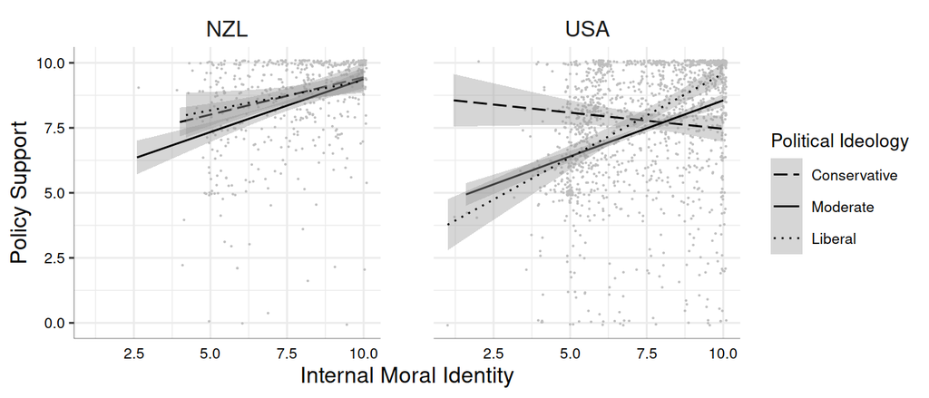

Figure 7: USA: Interaction between Political Ideology and Internal Moral Identity in predicting Policy Support

### USA Regression

This model was significant $R^2 = .29$, $F(17, 1430) = 34.81$, $p < .001$.

Table 13:

*Predictors of Policy Support in USA*

| predictor | $b$ | 95% CI | $t(1430)$ | $p$ |
| --- | --- | --- | --- | --- |
| Intercept | 1.34 | $[-0.21$, $2.90]$ | 1.69 | .090 |
| Age | 0.01 | $[0.01$, $0.02]$ | 3.40 | .001 |
| Sex - Male/Female | 0.18 | $[-0.04$, $0.40]$ | 1.63 | .104 |
| Sex - Other/Female | 0.84 | $[-1.15$, $2.84]$ | 0.83 | .408 |
| Risk Perception | 0.02 | $[0.01$, $0.02]$ | 7.80 | < .001 |
| Narcissism Admiration | 0.09 | $[0.03$, $0.15]$ | 2.84 | .005 |
| Narcissism Rivalry | 0.02 | $[-0.04$, $0.08]$ | 0.76 | .449 |
| Collective Narcissism | 0.09 | $[0.03$, $0.15]$ | 3.08 | .002 |
| Conspiracy Beliefs | -0.17 | $[-0.22$, $-0.13]$ | -7.21 | < .001 |
| National Identification | 0.10 | $[0.04$, $0.16]$ | 3.33 | .001 |
| Moral circle | -0.01 | $[-0.11$, $0.09]$ | -0.28 | .778 |
| Moral identity internal | 0.62 | $[0.44$, $0.80]$ | 6.62 | < .001 |
| Moral identity symbolic | -0.13 | $[-0.28$, $0.01]$ | -1.80 | .073 |
| Political ideology | 0.04 | $[-0.15$, $0.24]$ | 0.46 | .646 |
| Moral circle $\times$ Moral identity internal | 0.00 | $[-0.01$, $0.01]$ | 0.16 | .875 |
| Moral circle $\times$ Moral identity symbolic | 0.01 | $[0.00$, $0.02]$ | 1.37 | .171 |
| Moral identity internal $\times$ Political ideology | -0.06 | $[-0.08$, $-0.04]$ | -5.46 | < .001 |
| Moral identity symbolic $\times$ Political ideology | 0.05 | $[0.03$, $0.06]$ | 5.47 | < .001 |

### New Zealand Regression

This model was significant $R^2 = .21$, $F(17, 484) = 7.52$, $p < .001$.

Table 14:

*Predictors of Policy Support in New Zealand*

| predictor | $b$ | 95% CI | $t(484)$ | $p$ |
| --- | --- | --- | --- | --- |
| Intercept | 5.84 | $[3.12$, $8.57]$ | 4.21 | < .001 |
| Age | 0.00 | $[0.00$, $0.01]$ | 0.90 | .371 |
| Sex - Male/Female | 0.52 | $[0.21$, $0.84]$ | 3.28 | .001 |
| Sex - Other/Female | 0.94 | $[-2.40$, $4.29]$ | 0.56 | .579 |
| Risk Perception | 0.00 | $[0.00$, $0.01]$ | 0.61 | .542 |
| Narcissism Admiration | -0.03 | $[-0.12$, $0.06]$ | -0.70 | .485 |
| Narcissism Rivalry | 0.06 | $[-0.03$, $0.16]$ | 1.32 | .187 |
| Collective Narcissism | 0.11 | $[0.04$, $0.19]$ | 2.89 | .004 |
| Conspiracy Beliefs | -0.17 | $[-0.23$, $-0.10]$ | -5.23 | < .001 |
| National Identification | 0.10 | $[0.03$, $0.18]$ | 2.78 | .006 |
| Moral circle | 0.02 | $[-0.13$, $0.17]$ | 0.25 | .804 |
| Moral identity internal | 0.21 | $[-0.09$, $0.50]$ | 1.38 | .169 |
| Moral identity symbolic | -0.06 | $[-0.32$, $0.19]$ | -0.50 | .616 |
| Political ideology | -0.23 | $[-0.62$, $0.16]$ | -1.14 | .253 |
| Moral circle $\times$ Moral identity internal | 0.00 | $[-0.02$, $0.01]$ | -0.34 | .735 |
| Moral circle $\times$ Moral identity symbolic | 0.00 | $[-0.01$, $0.02]$ | 0.10 | .924 |
| Moral identity internal $\times$ Political ideology | 0.01 | $[-0.03$, $0.05]$ | 0.60 | .550 |
| Moral identity symbolic $\times$ Political ideology | 0.02 | $[-0.01$, $0.05]$ | 1.19 | .233 |

## Physical Contact

### Without Country

First I ran a regression for all variables across the full dataset (without accounting for Country). This model was significant $R^2 = .36$, $F(17, 1932) = 64.68$, $p < .001$.

Table 15:

*Predictors of Physical Contact (without Country)*

| predictor | $b$ | 95% CI | $t(1932)$ | $p$ |
| --- | --- | --- | --- | --- |
| Intercept | 4.48 | $[3.49$, $5.46]$ | 8.95 | < .001 |
| Age | 0.01 | $[0.01$, $0.01]$ | 4.55 | < .001 |
| Sex - Male/Female | 0.21 | $[0.07$, $0.34]$ | 3.05 | .002 |
| Sex - Other/Female | 0.40 | $[-0.86$, $1.65]$ | 0.62 | .535 |
| Risk Perception | 0.00 | $[0.00$, $0.00]$ | 1.50 | .134 |
| Narcissism Admiration | -0.01 | $[-0.05$, $0.03]$ | -0.52 | .600 |
| Narcissism Rivalry | -0.07 | $[-0.10$, $-0.03]$ | -3.53 | < .001 |
| Collective Narcissism | 0.02 | $[-0.01$, $0.05]$ | 1.12 | .263 |
| Conspiracy Beliefs | -0.11 | $[-0.14$, $-0.08]$ | -7.89 | < .001 |
| National Identification | 0.11 | $[0.07$, $0.15]$ | 6.11 | < .001 |
| Moral circle | -0.01 | $[-0.07$, $0.05]$ | -0.25 | .802 |
| Moral identity internal | 0.46 | $[0.35$, $0.57]$ | 7.98 | < .001 |
| Moral identity symbolic | -0.13 | $[-0.22$, $-0.03]$ | -2.70 | .007 |
| Political ideology | 0.02 | $[-0.11$, $0.14]$ | 0.29 | .768 |
| Moral circle $\times$ Moral identity internal | 0.00 | $[-0.01$, $0.00]$ | -0.92 | .357 |
| Moral circle $\times$ Moral identity symbolic | 0.01 | $[0.00$, $0.01]$ | 2.44 | .015 |
| Moral identity internal $\times$ Political ideology | -0.02 | $[-0.03$, $-0.01]$ | -2.71 | .007 |
| Moral identity symbolic $\times$ Political ideology | 0.02 | $[0.01$, $0.03]$ | 3.35 | .001 |

### With Country

Next I added Country as an interaction term. Again the model was significant $R^2 = .42$, $F(35, 1914) = 38.94$, $p < .001$. And the model performed significantly better than the previous model *F*(18, 1914) = 9.68, *p* < .001. Again a three way interaction was observed.

Table 16:

|  | predictor | $b$ | 95% CI | $t(1914)$ | $p$ |
| --- | --- | --- | --- | --- | --- |
| 29 | Country $\times$ Moral circle | 0.04 | $[-0.11$, $0.18]$ | 0.50 | .614 |

Table 17:

*Predictors of Physical Contact (with Country)*

| predictor | $b$ | 95% CI | $t(1914)$ | $p$ |
| --- | --- | --- | --- | --- |
| Intercept | 3.67 | $[2.61$, $4.72]$ | 6.82 | < .001 |
| Country | 3.41 | $[0.93$, $5.89]$ | 2.70 | .007 |
| Age | 0.01 | $[0.01$, $0.02]$ | 4.61 | < .001 |
| Sex - Male/Female | 0.24 | $[0.09$, $0.39]$ | 3.14 | .002 |
| Sex - Other/Female | 0.50 | $[-0.86$, $1.85]$ | 0.72 | .472 |
| Risk Perception | 0.01 | $[0.00$, $0.01]$ | 4.62 | < .001 |
| Narcissism Admiration | 0.01 | $[-0.04$, $0.05]$ | 0.24 | .807 |
| Narcissism Rivalry | -0.07 | $[-0.11$, $-0.03]$ | -3.62 | < .001 |
| Collective Narcissism | -0.01 | $[-0.05$, $0.03]$ | -0.55 | .585 |
| Conspiracy Beliefs | -0.10 | $[-0.13$, $-0.07]$ | -6.09 | < .001 |
| National Identification | 0.12 | $[0.08$, $0.16]$ | 5.84 | < .001 |
| Moral circle | -0.01 | $[-0.08$, $0.06]$ | -0.31 | .754 |
| Moral identity internal | 0.47 | $[0.35$, $0.60]$ | 7.41 | < .001 |
| Moral identity symbolic | -0.11 | $[-0.21$, $-0.01]$ | -2.13 | .033 |
| Political ideology | -0.01 | $[-0.14$, $0.12]$ | -0.08 | .934 |
| Moral circle $\times$ Moral identity internal | 0.00 | $[-0.01$, $0.01]$ | -0.49 | .625 |
| Moral circle $\times$ Moral identity symbolic | 0.01 | $[0.00$, $0.01]$ | 2.10 | .036 |
| Moral identity internal $\times$ Political ideology | -0.02 | $[-0.03$, $-0.01]$ | -2.67 | .008 |
| Moral identity symbolic $\times$ Political ideology | 0.02 | $[0.01$, $0.03]$ | 3.98 | < .001 |
| Country $\times$ Age | 0.00 | $[-0.01$, $0.01]$ | -0.60 | .545 |
| Country $\times$ Sex3male | 0.03 | $[-0.26$, $0.33]$ | 0.23 | .821 |
| Country $\times$ Sex3other | 0.93 | $[-2.14$, $3.99]$ | 0.59 | .554 |
| Country $\times$ Risk perception tot | -0.01 | $[-0.02$, $0.00]$ | -3.14 | .002 |
| Country $\times$ Narcissism admiration tot | 0.00 | $[-0.08$, $0.08]$ | 0.01 | .990 |
| Country $\times$ Narcissism rivalry tot | -0.04 | $[-0.13$, $0.05]$ | -0.87 | .383 |
| Country $\times$ Collective narcissism tot | 0.04 | $[-0.04$, $0.11]$ | 1.00 | .318 |
| Country $\times$ Conspiracy tot | 0.03 | $[-0.03$, $0.09]$ | 0.95 | .343 |
| Country $\times$ National ID tot | -0.05 | $[-0.12$, $0.03]$ | -1.23 | .220 |
| Country $\times$ Moral circle | 0.04 | $[-0.11$, $0.18]$ | 0.50 | .614 |
| Country $\times$ Moral identity internal | -0.28 | $[-0.56$, $-0.01]$ | -2.04 | .042 |
| Country $\times$ Moral identity symbolic | 0.01 | $[-0.22$, $0.24]$ | 0.10 | .918 |
| Country $\times$ Political ideology | -0.12 | $[-0.47$, $0.22]$ | -0.70 | .484 |
| Country $\times$ Moral circle $\times$ Moral identity internal | 0.00 | $[-0.02$, $0.01]$ | -0.38 | .708 |
| Country $\times$ Moral circle $\times$ Moral identity symbolic | -0.01 | $[-0.02$, $0.01]$ | -0.78 | .436 |
| Country $\times$ Moral identity internal $\times$ Political ideology | 0.04 | $[0.00$, $0.08]$ | 2.06 | .039 |
| Country $\times$ Moral identity symbolic $\times$ Political ideology | -0.02 | $[-0.05$, $0.01]$ | -1.26 | .209 |

### Plot

Figure 8 shows the relationship between Political Ideology and Internal Moral Identity in predicting Physical Contact for the New Zealand sample and the USA sample separately.

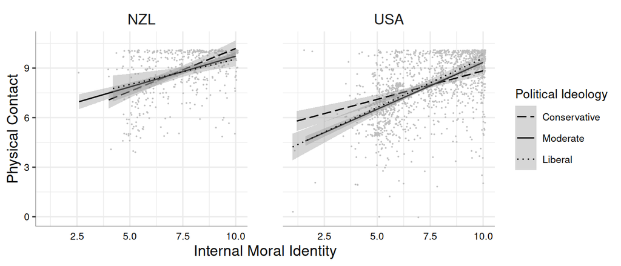

Figure 8: USA: Interaction between Political Ideology and Internal Moral Identity in predicting Physical Contact

### USA Regression

This model was significant $R^2 = .40$, $F(17, 1430) = 55.30$, $p < .001$.

Table 18:

*Predictors of Adherence to Physical Contact measures in USA*

| predictor | $b$ | 95% CI | $t(1430)$ | $p$ |
| --- | --- | --- | --- | --- |
| Intercept | 3.67 | $[2.58$, $4.76]$ | 6.60 | < .001 |
| Age | 0.01 | $[0.01$, $0.02]$ | 4.46 | < .001 |
| Sex - Male/Female | 0.24 | $[0.08$, $0.39]$ | 3.03 | .002 |
| Sex - Other/Female | 0.50 | $[-0.90$, $1.90]$ | 0.70 | .486 |
| Risk Perception | 0.01 | $[0.00$, $0.01]$ | 4.47 | < .001 |
| Narcissism Admiration | 0.01 | $[-0.04$, $0.05]$ | 0.24 | .813 |
| Narcissism Rivalry | -0.07 | $[-0.11$, $-0.03]$ | -3.50 | < .001 |
| Collective Narcissism | -0.01 | $[-0.05$, $0.03]$ | -0.53 | .598 |
| Conspiracy Beliefs | -0.10 | $[-0.13$, $-0.07]$ | -5.89 | < .001 |
| National Identification | 0.12 | $[0.08$, $0.17]$ | 5.64 | < .001 |
| Moral circle | -0.01 | $[-0.08$, $0.06]$ | -0.30 | .762 |
| Moral identity internal | 0.47 | $[0.34$, $0.60]$ | 7.17 | < .001 |
| Moral identity symbolic | -0.11 | $[-0.21$, $-0.01]$ | -2.06 | .040 |
| Political ideology | -0.01 | $[-0.14$, $0.13]$ | -0.08 | .937 |
| Moral circle $\times$ Moral identity internal | 0.00 | $[-0.01$, $0.01]$ | -0.47 | .636 |
| Moral circle $\times$ Moral identity symbolic | 0.01 | $[0.00$, $0.01]$ | 2.03 | .043 |
| Moral identity internal $\times$ Political ideology | -0.02 | $[-0.03$, $0.00]$ | -2.59 | .010 |
| Moral identity symbolic $\times$ Political ideology | 0.02 | $[0.01$, $0.04]$ | 3.85 | < .001 |

### New Zealand Regression

This model was significant $R^2 = .32$, $F(17, 484) = 13.40$, $p < .001$.

Table 19:

*Predictors of Adherence to Physical Contact measures in New Zealand*

| predictor | $b$ | 95% CI | $t(484)$ | $p$ |
| --- | --- | --- | --- | --- |
| Intercept | 7.08 | $[5.08$, $9.09]$ | 6.94 | < .001 |
| Age | 0.01 | $[0.00$, $0.02]$ | 2.72 | .007 |
| Sex - Male/Female | 0.27 | $[0.04$, $0.50]$ | 2.33 | .020 |
| Sex - Other/Female | 1.42 | $[-1.04$, $3.88]$ | 1.14 | .256 |
| Risk Perception | 0.00 | $[-0.01$, $0.00]$ | -1.22 | .223 |
| Narcissism Admiration | 0.01 | $[-0.06$, $0.07]$ | 0.17 | .867 |
| Narcissism Rivalry | -0.11 | $[-0.18$, $-0.04]$ | -3.21 | .001 |
| Collective Narcissism | 0.03 | $[-0.03$, $0.08]$ | 0.94 | .349 |
| Conspiracy Beliefs | -0.07 | $[-0.12$, $-0.02]$ | -2.96 | .003 |
| National Identification | 0.08 | $[0.02$, $0.13]$ | 2.81 | .005 |
| Moral circle | 0.03 | $[-0.09$, $0.14]$ | 0.45 | .651 |
| Moral identity internal | 0.19 | $[-0.03$, $0.40]$ | 1.68 | .093 |
| Moral identity symbolic | -0.10 | $[-0.28$, $0.09]$ | -1.01 | .314 |
| Political ideology | -0.13 | $[-0.42$, $0.16]$ | -0.88 | .377 |
| Moral circle $\times$ Moral identity internal | 0.00 | $[-0.02$, $0.01]$ | -0.77 | .444 |
| Moral circle $\times$ Moral identity symbolic | 0.00 | $[-0.01$, $0.01]$ | 0.21 | .831 |
| Moral identity internal $\times$ Political ideology | 0.02 | $[-0.01$, $0.05]$ | 1.25 | .213 |
| Moral identity symbolic $\times$ Political ideology | 0.00 | $[-0.02$, $0.03]$ | 0.35 | .726 |

## Physical Hygiene

### Without Country

First I ran a regression for all variables across the full dataset (without accounting for Country). This model was significant $R^2 = .27$, $F(17, 1931) = 41.61$, $p < .001$.

Table 20:

*Predictors of Physical Hygiene (without Country)*

| predictor | $b$ | 95% CI | $t(1931)$ | $p$ |
| --- | --- | --- | --- | --- |
| Intercept | 2.34 | $[1.21$, $3.46]$ | 4.08 | < .001 |
| Age | 0.00 | $[0.00$, $0.01]$ | 1.82 | .069 |
| Sex - Male/Female | 0.36 | $[0.20$, $0.51]$ | 4.56 | < .001 |
| Sex - Other/Female | -0.90 | $[-2.33$, $0.54]$ | -1.22 | .221 |
| Risk Perception | 0.01 | $[0.01$, $0.01]$ | 5.78 | < .001 |
| Narcissism Admiration | 0.08 | $[0.04$, $0.12]$ | 3.66 | < .001 |
| Narcissism Rivalry | -0.08 | $[-0.13$, $-0.04]$ | -4.00 | < .001 |
| Collective Narcissism | 0.10 | $[0.06$, $0.14]$ | 5.19 | < .001 |
| Conspiracy Beliefs | -0.05 | $[-0.08$, $-0.02]$ | -2.89 | .004 |
| National Identification | 0.12 | $[0.08$, $0.16]$ | 5.73 | < .001 |
| Moral circle | -0.04 | $[-0.11$, $0.04]$ | -0.98 | .329 |
| Moral identity internal | 0.32 | $[0.19$, $0.45]$ | 4.80 | < .001 |
| Moral identity symbolic | 0.13 | $[0.03$, $0.23]$ | 2.44 | .015 |
| Political ideology | 0.14 | $[0.00$, $0.29]$ | 1.99 | .047 |
| Moral circle $\times$ Moral identity internal | 0.00 | $[0.00$, $0.01]$ | 1.02 | .306 |
| Moral circle $\times$ Moral identity symbolic | 0.00 | $[0.00$, $0.01]$ | 0.50 | .618 |
| Moral identity internal $\times$ Political ideology | -0.03 | $[-0.04$, $-0.01]$ | -3.17 | .002 |
| Moral identity symbolic $\times$ Political ideology | 0.01 | $[0.00$, $0.02]$ | 1.68 | .094 |

### With Country

Next I added Country as an interaction term. Again the model was significant $R^2 = .28$, $F(35, 1913) = 21.76$, $p < .001$. And the model performed significantly better than the previous model *F*(18, 1913) = 2.47, *p* < .001. No three way interaction this time.

Table 21:

*Predictors of Physical Hygiene (with Country)*

| predictor | $b$ | 95% CI | $t(1913)$ | $p$ |
| --- | --- | --- | --- | --- |
| Intercept | 1.81 | $[-0.85$, $4.46]$ | 1.33 | .182 |
| Country | 0.46 | $[-2.47$, $3.39]$ | 0.31 | .757 |
| Age | 0.00 | $[-0.01$, $0.01]$ | -0.47 | .640 |
| Sex - Male/Female | 0.42 | $[0.12$, $0.73]$ | 2.71 | .007 |
| Sex - Other/Female | -0.41 | $[-3.66$, $2.84]$ | -0.25 | .804 |
| Risk Perception | 0.00 | $[-0.01$, $0.00]$ | -0.76 | .446 |
| Narcissism Admiration | 0.05 | $[-0.04$, $0.13]$ | 1.08 | .279 |
| Narcissism Rivalry | -0.09 | $[-0.18$, $0.00]$ | -1.88 | .060 |
| Collective Narcissism | 0.11 | $[0.04$, $0.19]$ | 2.92 | .004 |
| Conspiracy Beliefs | -0.01 | $[-0.07$, $0.06]$ | -0.17 | .861 |
| National Identification | 0.06 | $[-0.02$, $0.13]$ | 1.52 | .128 |
| Moral circle | 0.07 | $[-0.08$, $0.22]$ | 0.93 | .354 |
| Moral identity internal | 0.38 | $[0.09$, $0.66]$ | 2.56 | .011 |
| Moral identity symbolic | 0.31 | $[0.07$, $0.56]$ | 2.48 | .013 |
| Political ideology | 0.38 | $[0.00$, $0.76]$ | 1.95 | .052 |
| Moral circle $\times$ Moral identity internal | 0.00 | $[-0.02$, $0.02]$ | -0.01 | .991 |
| Moral circle $\times$ Moral identity symbolic | -0.01 | $[-0.03$, $0.00]$ | -1.58 | .114 |
| Moral identity internal $\times$ Political ideology | -0.05 | $[-0.09$, $-0.01]$ | -2.28 | .023 |
| Moral identity symbolic $\times$ Political ideology | 0.00 | $[-0.03$, $0.03]$ | -0.11 | .914 |
| Country $\times$ Age | 0.01 | $[0.00$, $0.02]$ | 1.50 | .133 |
| Country $\times$ Sex - Male/Female | -0.06 | $[-0.41$, $0.29]$ | -0.33 | .739 |
| Country $\times$ Sex - Other/Female | -0.74 | $[-4.37$, $2.88]$ | -0.40 | .688 |
| Country $\times$ Risk perception | 0.01 | $[0.01$, $0.02]$ | 3.28 | .001 |
| Country $\times$ Narcissism admiration | 0.03 | $[-0.07$, $0.13]$ | 0.60 | .547 |
| Country $\times$ Narcissism rivalry | 0.01 | $[-0.09$, $0.11]$ | 0.16 | .871 |
| Country $\times$ Collective narcissism | -0.01 | $[-0.09$, $0.08]$ | -0.12 | .901 |
| Country $\times$ Conspiracy | -0.05 | $[-0.12$, $0.02]$ | -1.44 | .151 |
| Country $\times$ National ID | 0.09 | $[0.00$, $0.17]$ | 1.98 | .048 |
| Country $\times$ Moral circle | -0.13 | $[-0.30$, $0.04]$ | -1.48 | .140 |
| Country $\times$ Moral identity internal | -0.05 | $[-0.37$, $0.28]$ | -0.28 | .783 |
| Country $\times$ Moral identity symbolic | -0.22 | $[-0.49$, $0.06]$ | -1.56 | .118 |
| Country $\times$ Political ideology | -0.25 | $[-0.65$, $0.16]$ | -1.18 | .240 |
| Country $\times$ Moral circle $\times$ Moral identity internal | 0.01 | $[-0.01$, $0.02]$ | 0.52 | .602 |
| Country $\times$ Moral circle $\times$ Moral identity symbolic | 0.02 | $[0.00$, $0.03]$ | 1.89 | .058 |
| Country $\times$ Moral identity internal $\times$ Political ideology | 0.02 | $[-0.02$, $0.07]$ | 0.98 | .327 |
| Country $\times$ Moral identity symbolic $\times$ Political ideology | 0.01 | $[-0.02$, $0.05]$ | 0.71 | .476 |

### Plot

Figure 9 shows the relationship between Political Ideology and Internal Moral Identity in predicting Physical Hygiene for the New Zealand sample and the USA sample separately (note that these effects are equivalent).

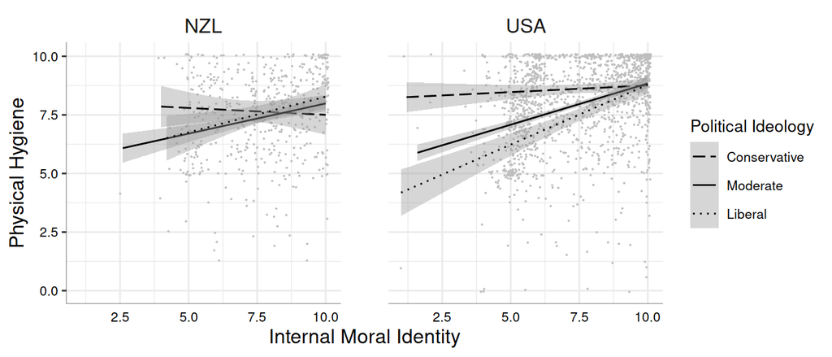

Figure 9: USA: Interaction between Political Ideology and Internal Moral Identity in predicting Physical Hygiene

### USA Regression

This model was significant $R^2 = .31$, $F(17, 1429) = 37.46$, $p < .001$.

Table 22:

*Predictors of Adherence to Physical Hygiene measures in USA*

| predictor | $b$ | 95% CI | $t(1429)$ | $p$ |
| --- | --- | --- | --- | --- |
| Intercept | 2.27 | $[1.05$, $3.49]$ | 3.65 | < .001 |
| Age | 0.01 | $[0.00$, $0.01]$ | 2.02 | .044 |
| Sex - Male/Female | 0.36 | $[0.19$, $0.53]$ | 4.10 | < .001 |
| Sex - Other/Female | -1.15 | $[-2.72$, $0.41]$ | -1.45 | .148 |
| Risk Perception | 0.01 | $[0.01$, $0.01]$ | 5.63 | < .001 |
| Narcissism Admiration | 0.08 | $[0.03$, $0.12]$ | 3.28 | .001 |
| Narcissism Rivalry | -0.08 | $[-0.12$, $-0.03]$ | -3.34 | .001 |
| Collective Narcissism | 0.11 | $[0.06$, $0.15]$ | 4.64 | < .001 |
| Conspiracy Beliefs | -0.06 | $[-0.09$, $-0.02]$ | -3.09 | .002 |
| National Identification | 0.14 | $[0.10$, $0.19]$ | 5.85 | < .001 |
| Moral circle | -0.06 | $[-0.14$, $0.02]$ | -1.43 | .154 |
| Moral identity internal | 0.33 | $[0.19$, $0.47]$ | 4.50 | < .001 |
| Moral identity symbolic | 0.09 | $[-0.02$, $0.21]$ | 1.61 | .107 |
| Political ideology | 0.13 | $[-0.02$, $0.28]$ | 1.72 | .086 |
| Moral circle $\times$ Moral identity internal | 0.00 | $[0.00$, $0.01]$ | 1.12 | .264 |
| Moral circle $\times$ Moral identity symbolic | 0.00 | $[0.00$, $0.01]$ | 1.09 | .276 |
| Moral identity internal $\times$ Political ideology | -0.03 | $[-0.04$, $-0.01]$ | -2.95 | .003 |
| Moral identity symbolic $\times$ Political ideology | 0.01 | $[0.00$, $0.02]$ | 1.62 | .106 |

### New Zealand Regression

This model was significant $R^2 = .17$, $F(17, 484) = 5.93$, $p < .001$.

Table 23:

*Predictors of Adherence to Physical Hygiene measures in New Zealand*

| predictor | $b$ | 95% CI | $t(484)$ | $p$ |
| --- | --- | --- | --- | --- |
| Intercept | 1.81 | $[-1.01$, $4.63]$ | 1.26 | .209 |
| Age | 0.00 | $[-0.01$, $0.01]$ | -0.44 | .660 |
| Sex - Male/Female | 0.42 | $[0.10$, $0.75]$ | 2.55 | .011 |
| Sex - Other/Female | -0.41 | $[-3.87$, $3.05]$ | -0.23 | .815 |
| Risk Perception | 0.00 | $[-0.01$, $0.00]$ | -0.72 | .472 |
| Narcissism Admiration | 0.05 | $[-0.04$, $0.14]$ | 1.02 | .308 |
| Narcissism Rivalry | -0.09 | $[-0.18$, $0.01]$ | -1.77 | .077 |
| Collective Narcissism | 0.11 | $[0.03$, $0.19]$ | 2.75 | .006 |
| Conspiracy Beliefs | -0.01 | $[-0.07$, $0.06]$ | -0.16 | .869 |
| National Identification | 0.06 | $[-0.02$, $0.13]$ | 1.43 | .152 |
| Moral circle | 0.07 | $[-0.09$, $0.23]$ | 0.87 | .383 |
| Moral identity internal | 0.38 | $[0.07$, $0.68]$ | 2.41 | .016 |
| Moral identity symbolic | 0.31 | $[0.05$, $0.57]$ | 2.34 | .020 |
| Political ideology | 0.38 | $[-0.03$, $0.78]$ | 1.84 | .067 |
| Moral circle $\times$ Moral identity internal | 0.00 | $[-0.02$, $0.02]$ | -0.01 | .992 |
| Moral circle $\times$ Moral identity symbolic | -0.01 | $[-0.03$, $0.00]$ | -1.49 | .137 |
| Moral identity internal $\times$ Political ideology | -0.05 | $[-0.09$, $0.00]$ | -2.15 | .032 |
| Moral identity symbolic $\times$ Political ideology | 0.00 | $[-0.04$, $0.03]$ | -0.10 | .919 |